# EDA on Haberman Dataset (Health care)

1.Download Haberman Cancer Survival dataset from Kaggle. You may have to create a Kaggle account to donwload data. (https://www.kaggle.com/gilsousa/habermans-survival-data-set)

2.Perform -High level statistics of the dataset: number of points, numer of features, number of classes, data-points per class.

3.Explain the objective.

4.Perform Univaraite analysis(PDF, CDF, Boxplot, Voilin plots) to understand which features are useful towards classification.

5.Perform Bi-variate analysis (scatter plots, pair-plots) to see if combinations of features are useful in classfication.

6.Write your observations in english as crisply and unambigously as possible. Always quantify your results.

1. Age of patient at time of operation (numerical)
2. Patient's year of operation (year - 1900, numerical)
3. Number of positive axillary nodes detected (numerical) --> A positive axillary node is a lymph node in the area of the armpit (axilla) to which cancer has spread. This spread is determined by surgically removing some of the lymph nodes and examining them under a microscope to see whether cancer cells are present.
4. Survival status (class attribute)

   ```
      -- 1 = the patient survived 5 years or longer
      -- 2 = the patient died within 5 year
   ```

```python
#importing required libraries
#naming the dataset name variable as hmds (haberman dataset)

import pandas as pd
import seaborn as sns
import matplotlib.pyplot as plt
import numpy as np

hmds=pd.read_csv("haberman.csv")
```

```python
print(hmds.shape)
#the output would be the number of (rows,columns)
```

```
(306, 4)
```

```python
print(hmds.columns)

#printing the columns; (the features in the dataset)
```

```
Index(['age', 'year', 'nodes', 'status'], dtype='object')
```

```python
#hmds["age"].value_counts()
#hmds["year"].value_counts()
#hmds["nodes"].value_counts()
hmds["status"].value_counts()

#datapoints per class
```

```
1    225
2     81
Name: status, dtype: int64
```

```python
#Counting number statuses will give us number of data points or total number of patients effected

print(225+81)


#number of classes: 2 (in status)

#number of features:3 (age, year, nodes)
```

```
306
```

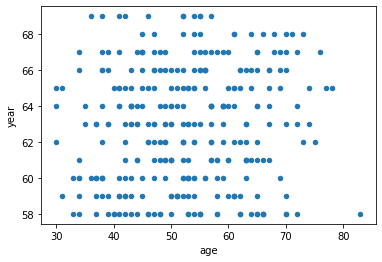

```python
hmds.plot(kind='scatter',x='age',y='year')
```

*Objective is to perform EDA on haberman dataset and obtain meaningful insights with the help of python libraries and programabily written mathematics.

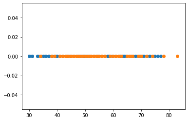

```python
#Status_1 = 1 -- patient survived more that 5 years
#Status_2 = 2 --patient survived less than 5 years

import numpy as np
status_1=hmds.loc[hmds["status"] == 1];
status_2=hmds.loc[hmds["status"] == 2];
plt.plot(status_1["age"],np.zeros_like(status_1["age"]),'o')
plt.plot(status_2["age"],np.zeros_like(status_2["age"]),'o')
plt.show()
```